# Visualizing the iris flower data set

Learning objectives:

- Basic concepts of R graphics
- Install and load R packages
- Basic plots with ggplot2
- Different ways to visualize the iris flower dataset

## Basic concepts of R graphics

We start with base R graphics. The first important distinction should be made about high- and low-level graphics functions in base R. High-level graphics functions initiate new plots, to which new elements could be added using the low-level functions. See table below.

High-level graphics functions initiate a new plot.

| Function | Description |
| --- | --- |
| plot | Generic plotting function |
| boxplot | boxplot. Can be applied to multiple columns of a matrix, or use equations boxplot( y ~ x) |
| hist | histogram |
| qqnorm | Quantile-quantile (Q-Q) plot to check for normality |
| curve | Graph an arithmetic function |
| barplot | Barplot |
| mosaicplot | Using mosaics to represent the frequencies of tabulated counts. |
| heatmap | Using colors to visualize a matrix of numeric values. |

In contrast, low-level graphics functions do not wipe out the existing plot; they add elements to it. The functions are listed below:

Low-level graphics functions that add elements to an existing plot.

| Function | Description |
| --- | --- |
| points | Add points to a plot |
| lines | Add lines to a plot |
| abline | Add a straight line |
| segments | Add line segments |
| text | Add text to a plot |
| legend | Add a legend to a plot |
| arrows | Add arrows to a plot |

Another distinction about data visualization is between plain, exploratory plots and refined, annotated ones. Both types are essential. Sometimes we generate many graphics for exploratory data analysis (EDA) to get some sense of what the data looks like. We can achieve this by using plotting functions with **default settings** to quickly generate a lot of “plain” plots. R is a very powerful EDA tool.

If we find something interesting about a dataset, we want to generate really “cool”-looking graphics for papers and presentations. Often we want to use a plot to convey a message to an audience. Making such plots typically requires a bit more coding, as you have to customize different parameters. For me, it usually involves lots of Google searches, copy-and-paste of example codes, and then lots of trial-and-error.

One of the open secrets of R programming is that you can start from a plain figure and **refine it step by step**. Here is an example using the base R graphics. This produces a basic scatter plot with the petal length on the x-axis and petal width on the y-axis. Since iris is a data frame, we will use the `iris$Petal.Length` to refer to the Petal.Length column.

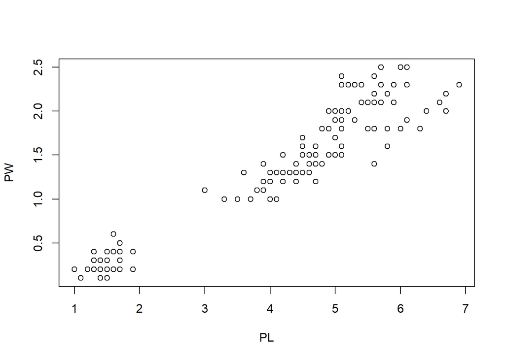

```r
PL <- iris$Petal.Length
PW <- iris$Petal.Width
plot(PL, PW)
```

To hange the type of symbols:

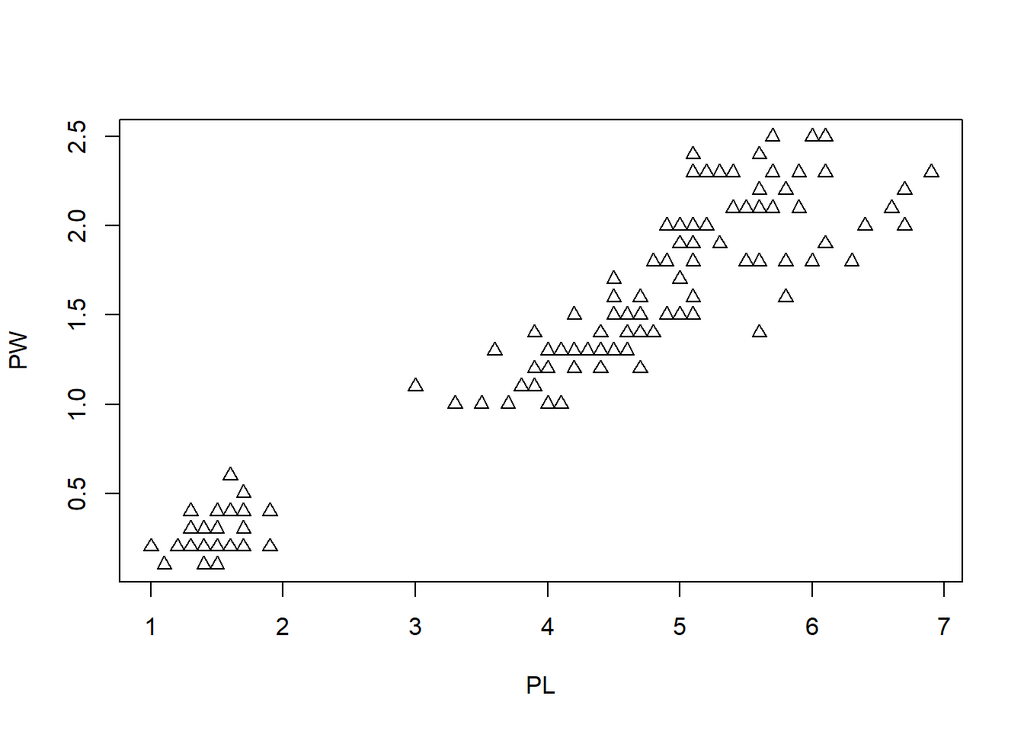

```r
plot(PL, PW, pch = 2) # pch = 2 means the symbol is triangle
```

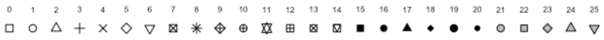

Points Symbols

There are many other parameters to the **plot** function in R. You can get these from the documentation:

```r
? plot
```

We can also change the color of the data points easily with the **col =** parameter.

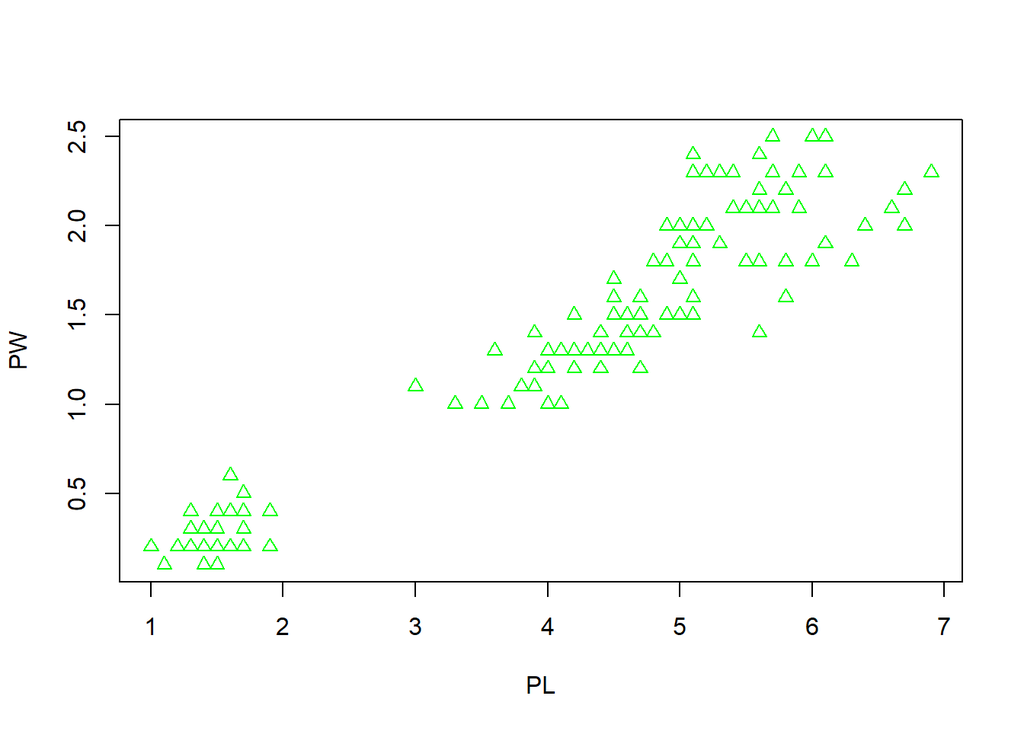

```r
plot(PL, PW, pch = 2, col = "green") # change the symbol color to green
```

Next, we can use different symbols for different species. First, extract the species information.

```r
iris$Species
```

```
##   [1] setosa     setosa     setosa     setosa     setosa     setosa
##   [7] setosa     setosa     setosa     setosa     setosa     setosa
##  [13] setosa     setosa     setosa     setosa     setosa     setosa
##  [19] setosa     setosa     setosa     setosa     setosa     setosa
##  [25] setosa     setosa     setosa     setosa     setosa     setosa
##  [31] setosa     setosa     setosa     setosa     setosa     setosa
##  [37] setosa     setosa     setosa     setosa     setosa     setosa
##  [43] setosa     setosa     setosa     setosa     setosa     setosa
##  [49] setosa     setosa     versicolor versicolor versicolor versicolor
##  [55] versicolor versicolor versicolor versicolor versicolor versicolor
##  [61] versicolor versicolor versicolor versicolor versicolor versicolor
##  [67] versicolor versicolor versicolor versicolor versicolor versicolor
##  [73] versicolor versicolor versicolor versicolor versicolor versicolor
##  [79] versicolor versicolor versicolor versicolor versicolor versicolor
##  [85] versicolor versicolor versicolor versicolor versicolor versicolor
##  [91] versicolor versicolor versicolor versicolor versicolor versicolor
##  [97] versicolor versicolor versicolor versicolor virginica  virginica
## [103] virginica  virginica  virginica  virginica  virginica  virginica
## [109] virginica  virginica  virginica  virginica  virginica  virginica
## [115] virginica  virginica  virginica  virginica  virginica  virginica
## [121] virginica  virginica  virginica  virginica  virginica  virginica
## [127] virginica  virginica  virginica  virginica  virginica  virginica
## [133] virginica  virginica  virginica  virginica  virginica  virginica
## [139] virginica  virginica  virginica  virginica  virginica  virginica
## [145] virginica  virginica  virginica  virginica  virginica  virginica
## Levels: setosa versicolor virginica
```

This output shows that the 150 observations are classed into three species *setosa*, *versicolor*, and *virginica*. If you are read theiris data from a file, like what we did in Chapter 1, the data type of the Species column is character. We need to convert this column into a **factor**.

```r
iris$Species <- as.factor(iris$Species)
str(iris$Species)
```

```
##  Factor w/ 3 levels "setosa","versicolor",..: 1 1 1 1 1 1 1 1 1 1 ...
```

Once convertetd into a factor, each observation is represented by one of the three levels of  
the three species *setosa*, *versicolor*, and *virginica*. **factors** are used to store categorical variables as levels. To completely convert this factor to numbers for plotting, we use the *as.numeric* function. Since we do not want to change the data frame, we will define a new variable called speciesID.

```r
speciesID <- as.numeric(iris$Species)
speciesID
```

```
##   [1] 1 1 1 1 1 1 1 1 1 1 1 1 1 1 1 1 1 1 1 1 1 1 1 1 1 1 1 1 1 1 1 1 1 1 1 1 1
##  [38] 1 1 1 1 1 1 1 1 1 1 1 1 1 2 2 2 2 2 2 2 2 2 2 2 2 2 2 2 2 2 2 2 2 2 2 2 2
##  [75] 2 2 2 2 2 2 2 2 2 2 2 2 2 2 2 2 2 2 2 2 2 2 2 2 2 2 3 3 3 3 3 3 3 3 3 3 3
## [112] 3 3 3 3 3 3 3 3 3 3 3 3 3 3 3 3 3 3 3 3 3 3 3 3 3 3 3 3 3 3 3 3 3 3 3 3 3
## [149] 3 3
```

We can assign different markers to different species by letting *pch = speciesID*.

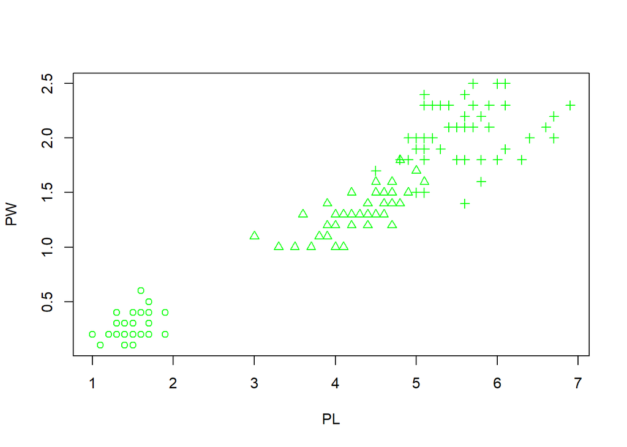

```r
plot(PL, PW, pch = speciesID, col = "green")
```

What happens here is that the 150 integers stored in the speciesID factor are used to alter marker types. The first 50 data points (*setosa*) are represented by open circles (pch = 1). The next 50 (*versicolor*) are represented by triangles (pch = 2), while the last 50 (*virginica*) are in crosses (pch = 3).